# Chiral Graviton Modes in Fractional Quantum Hall Liquids

Quantum Geometry, Spectral Sum Rules, and Polarization Selection Rules in R

John Akwei, Senior Data Scientist

2026-09-09

```r
library(ggplot2)
library(dplyr)
library(tidyr)
library(viridis)
library(gridExtra)

theme_set(theme_minimal())
```

# 1 Abstract

Chiral graviton modes (CGMs) are the long-wavelength, spin-2 limit of the Girvin–MacDonald–Platzman (GMP) magnetoroton in fractional quantum Hall (FQH) liquids. They are the quanta of fluctuations of Haldane’s *guiding-centre metric* — an internal, emergent geometric degree of freedom of the electron fluid, not of spacetime. This document (i) corrects and tightens a chat-export summary of the Nanjing University experiments, (ii) implements the exact topological bookkeeping that governs graviton chirality (Wen–Zee shift, guiding-centre spin, Haldane’s bound, the Golkar–Nguyen–Son spectral sum rules), and (iii) maps the genuine technical dependencies — as opposed to structural analogies — between this material and the existing repository documents `Gravitation.md`, `Gravitons_Gluons_Branes.md`, `Quantum_Chromodynamics_in_R.Rmd`, `Fracton_Codes_in_R.Rmd`, and `QuasiParticles_in_R.Rmd`.

The central quantitative result is that graviton chirality is **not** an observation to be reported — it is a **theorem** with a topological input. A non-negativity argument applied to two spectral densities forces $S_4 \ge |\mathcal{S}-1|/8$, and equality holds *if and only if* one circular polarization channel is empty. The experiment is a test of how close a real Coulomb ground state sits to that bound.

# 2 Epistemic flag convention

Carried over from `Gravitons_Gluons_Branes.md` for consistency across the repository.

- **[Established]** — experimental result or theorem; no serious dispute.
- **[Standard theory]** — mainstream theoretical result within its framework.
- **[Model]** — true within a specific trial wavefunction or effective model; not expected to hold for generic Hamiltonians.
- **[Conjectural]** — proposed but unproven.
- **[Corrected]** — the source chat transcript stated this incorrectly.
- **[Convention]** — sign or normalization depends on a stated choice; check against the cited paper before quoting a number.

# 3 What was actually measured

Two distinct experiments are conflated in the source transcript. They are two years apart and report different things. **[Corrected]**

|  | 2024 result | 2026 result |
| --- | --- | --- |
| Reference | Liang, Liu, Yang, Huang, Wurstbauer, Dean, West, Pfeiffer, Du, Pinczuk, *Nature* **628**, 78–83 (2024) | Yang, Wang, Lu, Liu, Baldwin, West, Pfeiffer, Yang, Balram, Du, *Nature Physics* (2026), doi:10.1038/s41567-026-03338-9 |
| Claim | First observation of a chiral spin-2 long-wavelength magnetoroton | Observation of *multiple* gravitons, incl. a high-energy mode |
| Fillings | $\nu = 1/3$ (and related) | $\nu = 1/4$, $2/7$, $2/9$ |
| Interpretation | Supports Haldane’s geometric description | Supports the **parton** construction of FQH states |
| Technique | Circularly polarized resonant inelastic light scattering (CP-RILS) | Same architecture |

## 3.1 Corrections to the source transcript

1. **“Chirality of $\pm 2$” was not observed.** **[Corrected]** The physical content is the opposite: at $\nu = 1/3$ the mode appears in *one* circular polarization channel only, corresponding to angular-momentum transfer $-2$. A fundamental graviton has *both* helicities $\pm 2$; the FQH mode is *maximally chiral*, and that asymmetry is the signature. For particle–hole conjugate states such as $\nu = 2/3$ the sign reverses to $+2$. **[Established]**
2. **“Behave precisely like the hypothetical fundamental graviton” is an overclaim.** **[Corrected]** What is shared is a single quantum number: charge $\pm 2$ under the $SO(2)$ rotation group of the plane. See §“What the CGM is not”.
3. **“First experimental evidence … published in Nature” dated to 2026.** **[Corrected]** The first evidence is the March 2024 *Nature* paper. The 2026 *Nature Physics* paper is a follow-up on partons.
4. **“Benchtop simulator to test the complex tensor mathematics behind quantum gravity.”** **[Corrected]** It tests Haldane’s geometric theory of the FQH effect. It supplies no information about graviton self-coupling, the Einstein–Hilbert action, or any UV completion of gravity.
5. **“Parton” is a false cognate with QCD.** **[Corrected]** In the FQH context (Jain 1989) partons are unphysical fractionally charged fermions into which an electron is formally decomposed and then reassembled. They are *not* the Feynman–Bjorken partons of `Quantum_Chromodynamics_in_R.Rmd`. Structural analogy only.
6. **Resonance is not incidental.** **[Established]** The “R” in CP-RILS matters: the light-scattering cross-section is only measurable when the laser is tuned near the fundamental optical transition of the GaAs quantum well. The transcript treats RILS as generic spectroscopy.
7. **A subtlety the transcript skips.** The GMP density-wave mode has *vanishing* spectral weight in the density channel as $q \to 0$. The reason a $q \to 0$ measurement is possible at all is the Golkar–Nguyen–Son result that the intensity in the **spin-2 (stress-tensor) channel** does not vanish at $q = 0$. Without that, the experiment would have no signal. **[Standard theory]**

# 4 Quantum geometry: why “spin-2” at all

Restricting to the lowest Landau level leaves only the guiding-centre coordinates $R^a$, which do not commute:

$$[R^a, R^b] = -i \ell_B^2 \epsilon^{ab},
\qquad \ell_B = \sqrt{\hbar / eB}.$$

Haldane’s observation is that the FQH ground state must choose a **unimodular metric** $g_{ab}$ ($\det g = 1$) to define the shape of the correlation hole around each guiding centre. A unimodular symmetric $2\times 2$ matrix has two free parameters, which package into a single complex field carrying charge $\pm 2$ under rotations. That is the entire origin of “spin-2.” **[Standard theory]**

Two consequences follow immediately, and both are worth stating because they close off the loose analogy in the source transcript:

- The metric is **internal** to the electron fluid, not a fluctuation of the ambient spacetime metric. The GaAs lattice is unaffected.
- “Spin-2” here means charge $2$ under $SO(2)$, the rotation group of a plane. A four-dimensional graviton lives in a spin-2 representation of the Lorentz group $SO(3,1)$, which is a strictly stronger statement. **[Established]**

# 5 Shift, guiding-centre spin, and Haldane’s bound

The topological input is the Wen–Zee shift $\mathcal{S}$, defined on the sphere by $N_\phi = \nu^{-1} N - \mathcal{S}$. The guiding-centre spin is $\bar{s} = (\mathcal{S} - 1)/2$.

Haldane’s inequality on the $q^4$ coefficient of the projected static structure factor is

$$S_4 \;\ge\; \frac{|\mathcal{S} -
1|}{8},$$

proven as a sum rule by Golkar, Nguyen and Son (*JHEP* **2016**, 21). **[Established]**

```r
# Shift formulas -------------------------------------------------------------
# Laughlin  nu = 1/m                 : S = m
# Jain forward-flux nu = n/(2pn + 1) : S = n + 2p
# Jain reverse-flux nu = n/(2pn - 1) : S = 2p - n
# [Standard theory] -- these are the standard LLL conventions.

fqh_states <- bind_rows(
  data.frame(family = "IQHE",     label = "1",    nu = 1,        S = 1),
  data.frame(family = "Laughlin", label = "1/3",  nu = 1/3,      S = 3),
  data.frame(family = "Laughlin", label = "1/5",  nu = 1/5,      S = 5),
  data.frame(family = "Laughlin", label = "1/7",  nu = 1/7,      S = 7),
  data.frame(family = "Jain +",   label = "2/5",  nu = 2/5,      S = 4),
  data.frame(family = "Jain +",   label = "3/7",  nu = 3/7,      S = 5),
  data.frame(family = "Jain +",   label = "2/9",  nu = 2/9,      S = 6),
  data.frame(family = "Jain -",   label = "2/3",  nu = 2/3,      S = 0),
  data.frame(family = "Jain -",   label = "3/5",  nu = 3/5,      S = -1),
  data.frame(family = "Jain -",   label = "2/7",  nu = 2/7,      S = 2)
) %>%
  mutate(
    s_bar        = (S - 1) / 2,
    S4_bound     = abs(S - 1) / 8,
    chirality    = ifelse(S == 1, 0, ifelse(S > 1, -2, +2)),
    chirality_lb = factor(chirality, levels = c(-2, 0, 2),
                          labels = c("-2", "none", "+2"))
  )

knitr::kable(
  fqh_states %>% select(family, label, S, s_bar, S4_bound, chirality),
  col.names = c("Family", "nu", "Shift S", "s-bar", "Haldane bound on S4",
                "Predicted chirality"),
  digits = 4,
  caption = "Topological bookkeeping for the chiral graviton mode."
)
```

Topological bookkeeping for the chiral graviton mode.

| Family | nu | Shift S | s-bar | Haldane bound on S4 | Predicted chirality |
| --- | --- | --- | --- | --- | --- |
| IQHE | 1 | 1 | 0.0 | 0.000 | 0 |
| Laughlin | 1/3 | 3 | 1.0 | 0.250 | -2 |
| Laughlin | 1/5 | 5 | 2.0 | 0.500 | -2 |
| Laughlin | 1/7 | 7 | 3.0 | 0.750 | -2 |
| Jain + | 2/5 | 4 | 1.5 | 0.375 | -2 |
| Jain + | 3/7 | 5 | 2.0 | 0.500 | -2 |
| Jain + | 2/9 | 6 | 2.5 | 0.625 | -2 |
| Jain - | 2/3 | 0 | -0.5 | 0.125 | 2 |
| Jain - | 3/5 | -1 | -1.0 | 0.250 | 2 |
| Jain - | 2/7 | 2 | 0.5 | 0.125 | -2 |

**Consistency checks.** Two independent facts must fall out, and they do:

- $\nu = 1$: $\mathcal{S} = 1 \Rightarrow \bar{s} = 0 \Rightarrow$ bound is $0$. The integer quantum Hall state has no graviton. This is the control model for the whole framework.
- $\nu = 2/3$: $\mathcal{S} = 0 \Rightarrow \mathcal{S} - 1 < 0 \Rightarrow$ chirality $+2$, opposite to $\nu = 1/3$. This reproduces the known particle–hole reversal without any additional input. **[Established]**

## 5.1 Laughlin saturation

For the Laughlin wavefunction at $\nu = 1/m$ the exact $q^4$ coefficient is $S_4 = (m-1)/8$, which equals $|\mathcal{S}-1|/8$ with $\mathcal{S} = m$. The model wavefunction saturates the bound exactly. **[Model]** — this is a property of the trial wavefunction, not of the Coulomb Hamiltonian.

```r
laughlin <- data.frame(m = c(1, 3, 5, 7)) %>%
  mutate(nu       = 1 / m,
         S        = m,
         S4_exact = (m - 1) / 8,
         S4_bound = abs(S - 1) / 8,
         saturated = isTRUE(all.equal(S4_exact, S4_bound)))

knitr::kable(laughlin, digits = 4,
             caption = "Laughlin states saturate Haldane's bound exactly.")
```

Laughlin states saturate Haldane’s bound exactly.

| m | nu | S | S4_exact | S4_bound | saturated |
| --- | --- | --- | --- | --- | --- |
| 1 | 1.0000 | 1 | 0.00 | 0.00 | TRUE |
| 3 | 0.3333 | 3 | 0.25 | 0.25 | TRUE |
| 5 | 0.2000 | 5 | 0.50 | 0.50 | TRUE |
| 7 | 0.1429 | 7 | 0.75 | 0.75 | TRUE |

```r
stopifnot(all(abs(laughlin$S4_exact - laughlin$S4_bound) < 1e-12))
```

# 6 The chiral spectral sum rules

Define two non-negative spectral densities $\rho_T^{(-)}(\omega)$ and $\rho_T^{(+)}(\omega)$, proportional to the absorption probabilities for gravitons of chirality $-2$ and $+2$ respectively. Their inverse-frequency moments,

$$\mathcal{J}_\mp \;=\; \int_0^\infty
\frac{d\omega}{2\pi}\,
\frac{\rho_T^{(\mp)}(\omega)}{\omega},$$

satisfy two sum rules. **[Convention]** — written here in the normalization that makes Haldane’s bound come out as stated; verify factors against Golkar–Nguyen–Son before quoting numerically:

$$\mathcal{J}_- - \mathcal{J}_+ \;=\;
\frac{\mathcal{S} - 1}{8},
\qquad\qquad
\mathcal{J}_- + \mathcal{J}_+ \;=\; S_4 .$$

The first is **topological** — fixed by the shift, independent of the Hamiltonian. The second is **dynamical** — it depends on the actual ground state. Because $\mathcal{J}_\pm \ge 0$ by construction, the two together give Haldane’s bound and, crucially, tell us that *saturation is equivalent to one channel being empty*.

Define the **chirality purity**

$$P \;=\; \frac{\mathcal{J}_- -
\mathcal{J}_+}{\mathcal{J}_- + \mathcal{J}_+}
\;=\; \frac{\mathcal{S} - 1}{8\,S_4}, \qquad P \in [-1, 1].$$

$|P| = 1$ is maximal chirality. This single number is what the CP-RILS polarization asymmetry is actually measuring.

```r
chiral_weights <- function(S, S4) {
  d  <- (S - 1) / 8
  Jm <- (S4 + d) / 2
  Jp <- (S4 - d) / 2
  if (Jm < -1e-12 || Jp < -1e-12)
    warning("S4 violates Haldane's bound for this shift; no valid state.")
  data.frame(S = S, S4 = S4, J_minus = Jm, J_plus = Jp,
             purity = (Jm - Jp) / (Jm + Jp))
}

scenarios <- bind_rows(
  cbind(case = "nu=1/3, Laughlin model wf",   chiral_weights(3, 1/4)),
  cbind(case = "nu=1/3, Coulomb (S4 larger)", chiral_weights(3, 0.30)),
  cbind(case = "nu=2/3, anti-Laughlin",       chiral_weights(0, 1/8)),
  cbind(case = "nu=2/7, single graviton",     chiral_weights(2, 1/8)),
  cbind(case = "nu=2/7, plus parton mode",    chiral_weights(2, 1/2))
)

knitr::kable(scenarios, digits = 4,
             caption = "Chiral spectral weights and purity. Purity = +/-1 means one polarization channel is empty.")
```

Chiral spectral weights and purity. Purity = +/-1 means one polarization channel is empty.

| case | S | S4 | J_minus | J_plus | purity |
| --- | --- | --- | --- | --- | --- |
| nu=1/3, Laughlin model wf | 3 | 0.250 | 0.2500 | 0.0000 | 1.0000 |
| nu=1/3, Coulomb (S4 larger) | 3 | 0.300 | 0.2750 | 0.0250 | 0.8333 |
| nu=2/3, anti-Laughlin | 0 | 0.125 | 0.0000 | 0.1250 | -1.0000 |
| nu=2/7, single graviton | 2 | 0.125 | 0.1250 | 0.0000 | 1.0000 |
| nu=2/7, plus parton mode | 2 | 0.500 | 0.3125 | 0.1875 | 0.2500 |

## 6.1 Reading the table

- **$\nu = 1/3$, model wavefunction**: $P = +1$. All weight in the $-2$ channel. This is the idealized statement.
- **$\nu = 1/3$, Coulomb**: numerics on Coulomb ground states find $S_4$ *above* the bound even at $\nu = 1/3$ and $1/5$, so $|P| < 1$ and both chiralities carry weight. **[Established, numerically]** The 2024 experiment therefore demonstrates *near*-maximal chirality, not exactly maximal. The source transcript does not make this distinction.
- **$\nu = 2/7$**: $\mathcal{S} = 2$, so the topological sum rule fixes the *net* weight at only $1/8$ — a small number. If the measured $S_4$ is substantially larger, the excess is forced into the *opposite*-chirality channel. That is precisely the room the second, high-energy graviton occupies. The 2026 multi-graviton observation is not merely compatible with the sum rules; it is the kind of thing the sum rules make room for. This is the Nguyen–Son argument: a Dirac composite-fermion description of $\nu = n/(4n \pm 1)$ violates Haldane’s bound unless an additional mode is added. **[Standard theory]**

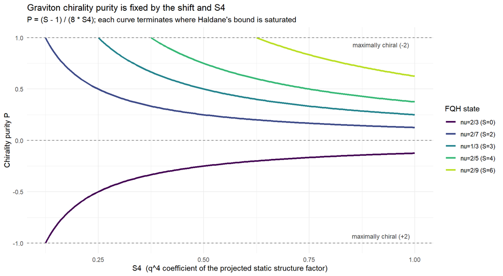

```r
grid <- expand.grid(S  = c(0, 2, 3, 4, 6),
                    S4 = seq(0.01, 1.0, by = 0.005)) %>%
  rowwise() %>%
  mutate(purity = (S - 1) / (8 * S4)) %>%
  ungroup() %>%
  filter(abs(purity) <= 1) %>%
  mutate(state = factor(S, levels = c(0, 2, 3, 4, 6),
                        labels = c("nu=2/3 (S=0)", "nu=2/7 (S=2)",
                                   "nu=1/3 (S=3)", "nu=2/5 (S=4)",
                                   "nu=2/9 (S=6)")))

ggplot(grid, aes(x = S4, y = purity, colour = state)) +
  geom_line(aes(colour = state), size = 1.1) +
  geom_hline(yintercept = c(-1, 0, 1), linetype = "dashed",
             colour = "grey45") +
  annotate("text", x = 0.92, y = 0.93, label = "maximally chiral (-2)",
           size = 3.2, colour = "grey25") +
  annotate("text", x = 0.92, y = -0.93, label = "maximally chiral (+2)",
           size = 3.2, colour = "grey25") +
  scale_colour_viridis_d(name = "FQH state", end = 0.9) +
  labs(
    title = "Graviton chirality purity is fixed by the shift and S4",
    subtitle = "P = (S - 1) / (8 * S4); each curve terminates where Haldane's bound is saturated",
    x = "S4  (q^4 coefficient of the projected static structure factor)",
    y = "Chirality purity P"
  ) +
  theme(legend.position = "right")
```

# 7 Long-wavelength structure factor and the $\nu = 1$ control

The projected static structure factor $\bar{S}(q)$ starts at fourth order:

$$\bar{S}(q\ell_B) \;=\; S_4 (q\ell_B)^4
\;+\; S_6 (q\ell_B)^6 \;+\; \dots$$

**Why this matters experimentally.** CP-RILS transfers momentum $q\ell_B \ll 1$. The experiment lives entirely inside the regime where the exact $S_4$ coefficient dominates — it is not probing the roton minimum near $q\ell_B \approx 1.4$. This is the direct link between the measurement and the topological bookkeeping above.

**A caution on $S_6$.** **[Corrected / Conjectural]** Effective-field-theory predictions for $S_6$ have been checked numerically and do *not* hold as equalities for generic FQH states. Do not treat $S_6$ as universal.

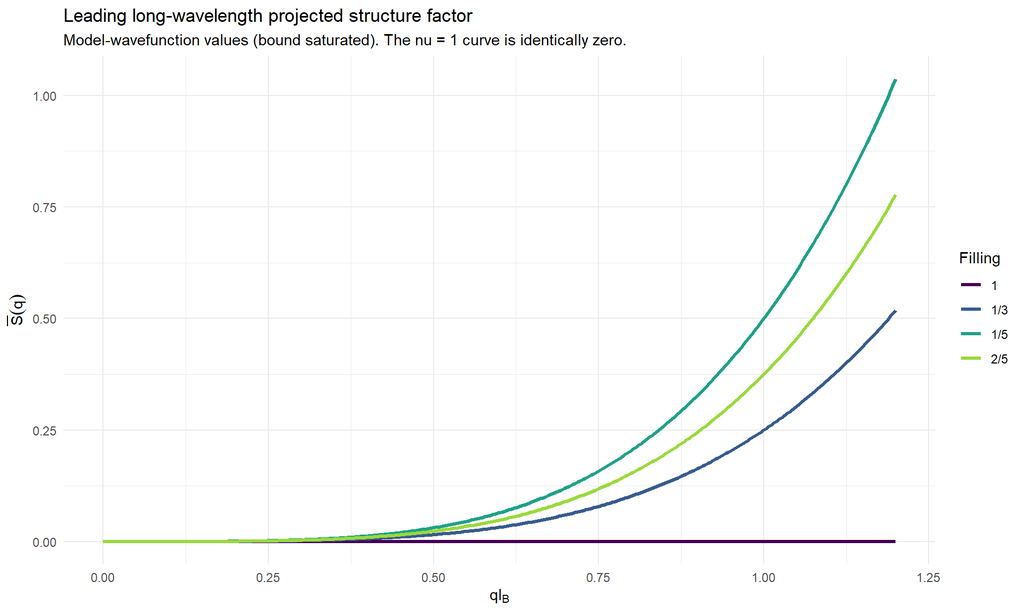

```r
x <- seq(0, 1.2, length.out = 300)   # x = q * l_B

sf_df <- fqh_states %>%
  filter(label %in% c("1", "1/3", "2/5", "1/5")) %>%
  select(label, S4_bound) %>%
  tidyr::crossing(x = x) %>%
  mutate(Sbar = S4_bound * x^4)

ggplot(sf_df, aes(x = x, y = Sbar, colour = label)) +
  geom_line(aes(colour = label), size = 1.1) +
  scale_colour_viridis_d(name = "Filling", end = 0.85) +
  labs(
    title = "Leading long-wavelength projected structure factor",
    subtitle = "Model-wavefunction values (bound saturated). The nu = 1 curve is identically zero.",
    x = expression(q * l[B]),
    y = expression(bar(S)(q))
  )
```

**Exact control calculation.** For $\nu = 1$ the full static structure factor is $S(q) = 1 - e^{-q^2\ell_B^2/2}$, and the projection subtracts exactly that term, giving $\bar{S}(q) \equiv 0$. No geometric degree of freedom, no graviton. This is an analytic benchmark, not a fit. **[Established]**

```r
S_full_nu1 <- function(x) 1 - exp(-x^2 / 2)
S_proj_nu1 <- function(x) S_full_nu1(x) - (1 - exp(-x^2 / 2))

max_dev <- max(abs(S_proj_nu1(seq(0, 5, length.out = 1001))))
cat(sprintf("Max |Sbar(q)| for nu = 1 over q*l_B in [0,5]:  %.3e\n", max_dev))
```

```
## Max |Sbar(q)| for nu = 1 over q*l_B in [0,5]:  0.000e+00
```

```r
stopifnot(max_dev < 1e-12)
```

The single-mode approximation dispersion is $\Delta(q) = \bar{f}(q) / \bar{S}(q)$, with $\bar{f}(q)$ the projected oscillator strength. Evaluating it requires the Laughlin pair correlation function $g(r)$, which is **not** computed here; a hypernetted-chain or sphere-geometry exact-diagonalization implementation is deferred (see Roadmap).

# 8 Polarization selection rules

The measurement is angular-momentum bookkeeping on photons. Writing $L_{\rm in}$ and $L_{\rm out}$ for the photon angular momenta along the field axis, the transfer to the electron liquid is $\Delta L = L_{\rm in} - L_{\rm out}$.

```r
sel <- expand.grid(L_in = c(-1, 1), L_out = c(-1, 1)) %>%
  mutate(
    dL      = L_in - L_out,
    channel = ifelse(dL == 0, "spin-0 (density)", "spin-2 (graviton)"),
    couples = case_when(
      dL ==  0 ~ "charge-density excitations",
      dL == -2 ~ "chiral graviton, chirality -2",
      dL == +2 ~ "chiral graviton, chirality +2"
    )
  )

knitr::kable(sel, digits = 0,
             col.names = c("L_in", "L_out", "Delta L", "Channel", "Couples to"),
             caption = "CP-RILS angular momentum bookkeeping.")
```

CP-RILS angular momentum bookkeeping.

| L_in | L_out | Delta L | Channel | Couples to |
| --- | --- | --- | --- | --- |
| -1 | -1 | 0 | spin-0 (density) | charge-density excitations |
| 1 | -1 | 2 | spin-2 (graviton) | chiral graviton, chirality +2 |
| -1 | 1 | -2 | spin-2 (graviton) | chiral graviton, chirality -2 |
| 1 | 1 | 0 | spin-0 (density) | charge-density excitations |

At $\nu = 1/3$ the signal appears only in the $\Delta L = -2$ channel. **[Established]**

**[Convention]** Mapping optical *handedness* ($\sigma^\pm$) onto photon angular momentum $L = \pm 1$ depends on propagation direction. In a backscattering geometry the outgoing photon travels along $-z$, which flips the handedness-to-$L_z$ assignment. State results in terms of $L$, not handedness, or the sign of the reported chirality can invert. This is a real source of confusion in the secondary literature.

# 9 What the CGM is not

The Weinberg-type argument reproduced in `Claude_AI_Science_Chats.txt` (“Spin-2 Particle and the Mathematics of Gravity”) concludes that a consistent theory of *massless* spin-2 particles in four dimensions coupling to a conserved $T^{\mu\nu}$ must be general relativity. It is worth being explicit that **none of the premises hold** for the CGM. **[Established]**

| Property of a fundamental graviton | CGM in an FQH liquid |
| --- | --- |
| Massless | **Gapped** — the mode sits at the magnetoroton gap |
| Both helicities $\pm 2$ | **Single dominant chirality**, set by the shift |
| Spin-2 of the Lorentz group $SO(3,1)$ | Charge-2 of the planar rotation group $SO(2)$ |
| Universal coupling to $T^{\mu\nu}$ | Couples to the internal guiding-centre metric only |
| Diffeomorphism invariance | Absent; the host lattice and $\mathbf{B}$ pick a frame |
| Long-range $1/r^2$ force | None; the mode is gapped and neutral |
| Lorentz invariance | Absent; non-relativistic, strong magnetic field |
| Self-interacting per Einstein–Hilbert | No analogue established |

So the shared structure is exactly one quantum number. The physics that *is* genuinely transferable is the **response to a background metric perturbation** — Hall viscosity, $\eta_H = \tfrac{\hbar}{4}\bar{s}\,\bar{n}$ (Read–Rezayi), is a bona fide geometric response function and is the honest bridge between this material and gravitational physics. **[Standard theory]**

# 10 Connections to the repository

## 10.1 Genuine technical dependencies

**`Gravitons_Gluons_Branes.md` — measuring gravitational quantities with non-gravitational probes.** The proton’s gravitational form factors $A(t), B(t), D(t)$ are matrix elements of $T^{\mu\nu}$ extracted from DVCS and near-threshold $J/\psi$ photoproduction — electromagnetic experiments delivering the proton’s coupling to a graviton. The CGM measurement is the same methodological move in condensed matter: a spin-2 stress-tensor observable extracted from an optical probe. In both cases the operator, not the force, is what is accessed. This is a real parallel, not decorative.

**Hall viscosity and the $D$-term.** Both are stress-response coefficients obtained from the same energy–momentum operator; $\bar{s}$ plays the role in FQH that the orbital-spin decomposition plays in Ji’s sum rule. Worth a side-by-side treatment.

**`Fracton_Codes_in_R.Rmd` — the guiding-centre algebra.** The LLL projected density operators close on the GMP algebra, a $W_\infty$ / area-preserving diffeomorphism algebra. Dipole-conserving field theories — the parent structures of fracton mobility restrictions — arise from the same multipole-constraint logic (Gromov; Nguyen–Gromov–Moroz; Prem–Pretko). The mobility restriction of a fracton and the LLL constraint that ties an excitation’s dipole moment to its position are the *same* algebraic mechanism. **Genuine dependency.**

Pretko’s “emergent gravity from symmetric tensor gauge theory” is a *different* and much weaker claim, and should not be merged with the above. **Structural analogy, flag as such.**

## 10.2 Structural analogies only

- **`Quantum_Chromodynamics_in_R.Rmd` — partons.** False cognate, as noted above. Flag explicitly wherever both documents are cited together.
- **`Gravitation.md` — Scherk’s graviphoton.** Both concern spin content of gravitational multiplets, but the graviphoton is a spin-1 field in extended supergravity, and no FQH construction produces it. No dependency.
- **`Quasiparticle_Rectification.md` — energy transport.** The CGM is neutral and gapped, so it carries energy without charge. Whether that is useful for anything is unestablished; the thermodynamic constraints in that document are unaffected. **[Conjectural]** — do not develop without a concrete transport calculation.

## 10.3 Frontier items for `QuasiParticles_in_R.Rmd`

Chiral graviton modes have moved into fractional Chern insulators and moiré systems during 2026:

- Long, Lu, Wu, Meng, *Phys. Rev. B* **113**, L041108 (2026) — magnetoroton and CGM spectra in fractional Chern insulators.
- Shen et al., *Phys. Rev. B* **113**, L081403 (2026) — magnetorotons in moiré fractional Chern insulators.
- CGMs in non-Abelian lattice FQH states (bosonic Harper–Hofstadter at unit filling, Moore–Read ground state), arXiv:2607.06267.

The Moore–Read / anti-Pfaffian discrimination by graviton chirality is the sharpest open experimental target: the two candidates at $\nu = 5/2$ carry *opposite* graviton chirality, so CP-RILS is in principle a direct topological-order discriminator. **[Standard theory, experimentally open]**

# 11 Roadmap

1. **Sphere-geometry exact diagonalization** of the hard-core ($V_1$) pseudopotential Hamiltonian at $\nu = 1/3$ for $N = 4$–$6$ electrons. $N_\phi = 3(N-1)$, so $N=6$ gives $\binom{16}{6} = 8008$ basis states — comfortably in range for R. Extract the exact Laughlin ground state, the $L = 2$ graviton, and $\bar{S}(q)$ directly. This would make $S_4$ a *computed* rather than *quoted* quantity and would verify the saturation claim numerically. Requires Wigner $3j$ symbols and Haldane pseudopotentials.
2. **Cross-check the Coulomb non-saturation result** (arXiv:2304.14991) at $\nu = 1/3$ by comparing $V_1$-only against a truncated Coulomb pseudopotential set — the same “compare against a simpler control model” pattern used in `QET_Subsystem_Symmetry_in_R.Rmd`.
3. **GMP single-mode approximation dispersion** once $g(r)$ is available from step 1; recover the roton minimum near $q\ell_B \approx 1.4$.
4. **Verify the sum-rule normalization** in §“The chiral spectral sum rules” against Golkar–Nguyen–Son eq. numbering, and remove the **[Convention]** flag once confirmed.
5. **Hall viscosity / $D$-term comparison section** bridging this document and `Gravitons_Gluons_Branes.md`.

# 12 References

**Experiment**

- Liang, J., Liu, Z., Yang, Z., Huang, Y., Wurstbauer, U., Dean, C. R., West, K. W., Pfeiffer, L. N., Du, L., & Pinczuk, A. (2024). Evidence for chiral graviton modes in fractional quantum Hall liquids. *Nature* **628**, 78–83.
- Yang, Z., Wang, Y., Lu, X., Liu, Z., Baldwin, K. W., West, K. W., Pfeiffer, L. N., Yang, B., Balram, A. C., & Du, L. (2026). Emergent partons in fractional quantum Hall systems. *Nature Physics*, doi:10.1038/s41567-026-03338-9.
- Pinczuk, A., Dennis, B. S., Pfeiffer, L. N., & West, K. W. (1993). Observation of collective excitations in the fractional quantum Hall effect. *Phys. Rev. Lett.* **70**, 3983.

**Companion documents in this repository**

`Gravitation.md` · `Gravitons_Gluons_Branes.md` · `Quantum_Chromodynamics_in_R.Rmd` · `Fracton_Codes_in_R.Rmd` · `QuasiParticles_in_R.Rmd` · `QET_Subsystem_Symmetry_in_R.Rmd`

*AI-assistance disclosure: the corrections, sum-rule bookkeeping, and repository cross-references in this document were developed in an AI-assisted session. Every numerical claim is either reproduced by the code blocks above or flagged for verification against the cited primary source. Items still requiring verification are listed in the Roadmap.*